# Distribution Tables

## Normal distribution

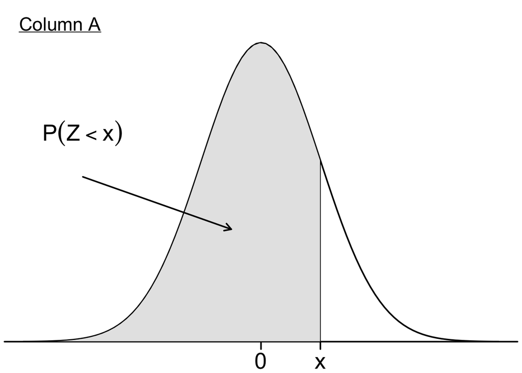

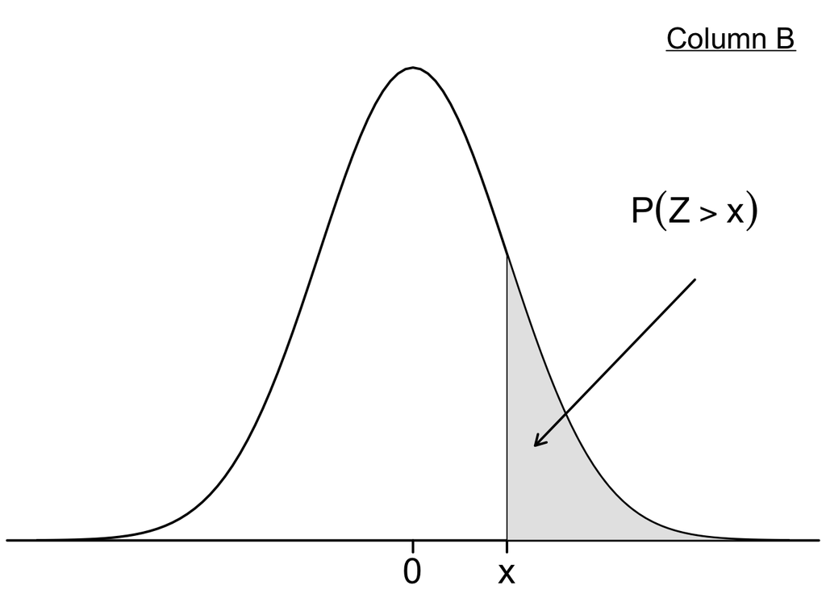

Use this table to look up probabilities for the standard normal distribution. Locate your Z-score in the x column to find the corresponding area to the left (Column A) or the area to the right (Column B). The table is scrollable, and you can use the search function in your browser to jump to a specific value.

Normal Distribution

| x | A P(Z < x) | B P(Z > x) |
| --- | --- | --- |
| 0.00 | 0.5000 | 0.5000 |
| 0.01 | 0.5040 | 0.4960 |
| 0.02 | 0.5080 | 0.4920 |
| 0.03 | 0.5120 | 0.4880 |
| 0.04 | 0.5160 | 0.4840 |
| 0.05 | 0.5199 | 0.4801 |
| 0.06 | 0.5239 | 0.4761 |
| 0.07 | 0.5279 | 0.4721 |
| 0.08 | 0.5319 | 0.4681 |
| 0.09 | 0.5359 | 0.4641 |
| 0.10 | 0.5398 | 0.4602 |
| 0.11 | 0.5438 | 0.4562 |
| 0.12 | 0.5478 | 0.4522 |
| 0.13 | 0.5517 | 0.4483 |
| 0.14 | 0.5557 | 0.4443 |
| 0.15 | 0.5596 | 0.4404 |
| 0.16 | 0.5636 | 0.4364 |
| 0.17 | 0.5675 | 0.4325 |
| 0.18 | 0.5714 | 0.4286 |
| 0.19 | 0.5753 | 0.4247 |
| 0.20 | 0.5793 | 0.4207 |
| 0.21 | 0.5832 | 0.4168 |
| 0.22 | 0.5871 | 0.4129 |
| 0.23 | 0.5910 | 0.4090 |
| 0.24 | 0.5948 | 0.4052 |
| 0.25 | 0.5987 | 0.4013 |
| 0.26 | 0.6026 | 0.3974 |
| 0.27 | 0.6064 | 0.3936 |
| 0.28 | 0.6103 | 0.3897 |
| 0.29 | 0.6141 | 0.3859 |

[output cut: 348 more lines]

Note: Column A is the area to the left; Column B is the area to the right.

## Binomial distribution

Use this table to look up probabilities for the binomial distribution. The table is scrollable, and you can use the search function in your browser to jump to a specific value.

This table provides the probability of exactly $k$ occurrences in $n$ independent trials, where each trial has a probability of success $p$.

1. **Locate the Number of Trials ($n$):** Find the horizontal section header for your specific $n$ (e.g., n = 3).
2. **Select the Probability of Success ($p$):** Move across the top bold header to find the column for your probability (e.g., .25).
3. **Identify the Number of Successes ($k$):** Find the row within your $n$ section corresponding to the number of successes you are looking for in the first bold column.
4. **Find the Intersection:** The value at the intersection of the $p$ column and $k$ row is your probability, $P(X = k)$

These probabilities can also be calculated using the equation for the probability mass function:

$P(X = k) = \binom{n}{k} p^k (1-p)^{n-k}$

Binomial Distribution Probabilities

P(X = k) for n trials with success probability p

| **k** | **p** 0.05 | **p** 0.10 | **p** 0.15 | **p** 0.20 | **p** 0.25 | **p** 0.30 | **p** 0.35 | **p** 0.40 | **p** 0.45 | **p** 0.50 |
| --- | --- | --- | --- | --- | --- | --- | --- | --- | --- | --- |
| n = 2 |  |  |  |  |  |  |  |  |  |  |
| 0 | .9025 | .8100 | .7225 | .6400 | .5625 | .4900 | .4225 | .3600 | .3025 | .2500 |
| 1 | .0950 | .1800 | .2550 | .3200 | .3750 | .4200 | .4550 | .4800 | .4950 | .5000 |
| 2 | .0025 | .0100 | .0225 | .0400 | .0625 | .0900 | .1225 | .1600 | .2025 | .2500 |
| n = 3 |  |  |  |  |  |  |  |  |  |  |
| 0 | .8574 | .7290 | .6141 | .5120 | .4219 | .3430 | .2746 | .2160 | .1664 | .1250 |
| 1 | .1354 | .2430 | .3251 | .3840 | .4219 | .4410 | .4436 | .4320 | .4084 | .3750 |
| 2 | .0071 | .0270 | .0574 | .0960 | .1406 | .1890 | .2389 | .2880 | .3341 | .3750 |
| 3 | .0001 | .0010 | .0034 | .0080 | .0156 | .0270 | .0429 | .0640 | .0911 | .1250 |
| n = 4 |  |  |  |  |  |  |  |  |  |  |
| 0 | .8145 | .6561 | .5220 | .4096 | .3164 | .2401 | .1785 | .1296 | .0915 | .0625 |
| 1 | .1715 | .2916 | .3685 | .4096 | .4219 | .4116 | .3845 | .3456 | .2995 | .2500 |
| 2 | .0135 | .0486 | .0975 | .1536 | .2109 | .2646 | .3105 | .3456 | .3675 | .3750 |
| 3 | .0005 | .0036 | .0115 | .0256 | .0469 | .0756 | .1115 | .1536 | .2005 | .2500 |
| 4 | .0000 | .0001 | .0005 | .0016 | .0039 | .0081 | .0150 | .0256 | .0410 | .0625 |
| n = 5 |  |  |  |  |  |  |  |  |  |  |
| 0 | .7738 | .5905 | .4437 | .3277 | .2373 | .1681 | .1160 | .0778 | .0503 | .0312 |
| 1 | .2036 | .3281 | .3915 | .4096 | .3955 | .3602 | .3124 | .2592 | .2059 | .1562 |
| 2 | .0214 | .0729 | .1382 | .2048 | .2637 | .3087 | .3364 | .3456 | .3369 | .3125 |
| 3 | .0011 | .0081 | .0244 | .0512 | .0879 | .1323 | .1811 | .2304 | .2757 | .3125 |
| 4 | .0000 | .0004 | .0022 | .0064 | .0146 | .0284 | .0488 | .0768 | .1128 | .1562 |
| 5 | .0000 | .0000 | .0001 | .0003 | .0010 | .0024 | .0053 | .0102 | .0185 | .0312 |
| n = 6 |  |  |  |  |  |  |  |  |  |  |
| 0 | .7351 | .5314 | .3771 | .2621 | .1780 | .1176 | .0754 | .0467 | .0277 | .0156 |
| 1 | .2321 | .3543 | .3993 | .3932 | .3560 | .3025 | .2437 | .1866 | .1359 | .0938 |
| 2 | .0305 | .0984 | .1762 | .2458 | .2966 | .3241 | .3280 | .3110 | .2780 | .2344 |
| 3 | .0021 | .0146 | .0415 | .0819 | .1318 | .1852 | .2355 | .2765 | .3032 | .3125 |
| 4 | .0001 | .0012 | .0055 | .0154 | .0330 | .0595 | .0951 | .1382 | .1861 | .2344 |
| 5 | .0000 | .0001 | .0004 | .0015 | .0044 | .0102 | .0205 | .0369 | .0609 | .0938 |
| 6 | .0000 | .0000 | .0000 | .0001 | .0002 | .0007 | .0018 | .0041 | .0083 | .0156 |

[output cut: 217 more lines]

## Poisson distribution

Use this table to look up probabilities for the poisson distribution. The table is scrollable, and you can use the search function in your browser to jump to a specific value.

This table provides the probability of exactly $k$ occurrences given an average rate ($\lambda$).

1. **Select your rate ($\lambda$):** Locate $\lambda$ across the top bold header.
2. **Identify your number of events/occurances ($k$):** Find the number of events in the first bold column on the left.
3. **Find the Probability:** The intersection of your chosen $\lambda$ and $k$ is the probability.

These probabilities can also be calculated using the equation for the probability mass function:

$P(X = k) = \frac{e^{-\lambda} \lambda^k}{k!}$

Poisson Distribution Probabilities

P(X = k) for various values of λ

| **k** | **λ** 0.5 | **λ** 1.0 | **λ** 1.5 | **λ** 2.0 | **λ** 2.5 | **λ** 3.0 | **λ** 3.5 | **λ** 4.0 | **λ** 4.5 | **λ** 5.0 | **λ** 5.5 | **λ** 6.0 | **λ** 6.5 | **λ** 7.0 | **λ** 7.5 | **λ** 8.0 | **λ** 8.5 | **λ** 9.0 | **λ** 9.5 | **λ** 10.0 | **λ** 10.5 | **λ** 11.0 | **λ** 11.5 | **λ** 12.0 | **λ** 12.5 | **λ** 13.0 | **λ** 13.5 | **λ** 14.0 | **λ** 14.5 | … |
| --- | --- | --- | --- | --- | --- | --- | --- | --- | --- | --- | --- | --- | --- | --- | --- | --- | --- | --- | --- | --- | --- | --- | --- | --- | --- | --- | --- | --- | --- | --- |
| 0 | .6065 | .3679 | .2231 | .1353 | .0821 | .0498 | .0302 | .0183 | .0111 | .0067 | .0041 | .0025 | .0015 | .0009 | .0006 | .0003 | .0002 | .0001 | .0001 | .0000 | .0000 | .0000 | .0000 | .0000 | .0000 | .0000 | .0000 | .0000 | .0000 | … |
| 1 | .3033 | .3679 | .3347 | .2707 | .2052 | .1494 | .1057 | .0733 | .0500 | .0337 | .0225 | .0149 | .0098 | .0064 | .0041 | .0027 | .0017 | .0011 | .0007 | .0005 | .0003 | .0002 | .0001 | .0001 | .0000 | .0000 | .0000 | .0000 | .0000 | … |
| 2 | .0758 | .1839 | .2510 | .2707 | .2565 | .2240 | .1850 | .1465 | .1125 | .0842 | .0618 | .0446 | .0318 | .0223 | .0156 | .0107 | .0074 | .0050 | .0034 | .0023 | .0015 | .0010 | .0007 | .0004 | .0003 | .0002 | .0001 | .0001 | .0001 | … |
| 3 | .0126 | .0613 | .1255 | .1804 | .2138 | .2240 | .2158 | .1954 | .1687 | .1404 | .1133 | .0892 | .0688 | .0521 | .0389 | .0286 | .0208 | .0150 | .0107 | .0076 | .0053 | .0037 | .0026 | .0018 | .0012 | .0008 | .0006 | .0004 | .0003 | … |
| 4 | .0016 | .0153 | .0471 | .0902 | .1336 | .1680 | .1888 | .1954 | .1898 | .1755 | .1558 | .1339 | .1118 | .0912 | .0729 | .0573 | .0443 | .0337 | .0254 | .0189 | .0139 | .0102 | .0074 | .0053 | .0038 | .0027 | .0019 | .0013 | .0009 | … |
| 5 | .0002 | .0031 | .0141 | .0361 | .0668 | .1008 | .1322 | .1563 | .1708 | .1755 | .1714 | .1606 | .1454 | .1277 | .1094 | .0916 | .0752 | .0607 | .0483 | .0378 | .0293 | .0224 | .0170 | .0127 | .0095 | .0070 | .0051 | .0037 | .0027 | … |
| 6 | .0000 | .0005 | .0035 | .0120 | .0278 | .0504 | .0771 | .1042 | .1281 | .1462 | .1571 | .1606 | .1575 | .1490 | .1367 | .1221 | .1066 | .0911 | .0764 | .0631 | .0513 | .0411 | .0325 | .0255 | .0197 | .0152 | .0115 | .0087 | .0065 | … |
| 7 | .0000 | .0001 | .0008 | .0034 | .0099 | .0216 | .0385 | .0595 | .0824 | .1044 | .1234 | .1377 | .1462 | .1490 | .1465 | .1396 | .1294 | .1171 | .1037 | .0901 | .0769 | .0646 | .0535 | .0437 | .0353 | .0281 | .0222 | .0174 | .0135 | … |
| 8 | .0000 | .0000 | .0001 | .0009 | .0031 | .0081 | .0169 | .0298 | .0463 | .0653 | .0849 | .1033 | .1188 | .1304 | .1373 | .1396 | .1375 | .1318 | .1232 | .1126 | .1009 | .0888 | .0769 | .0655 | .0551 | .0457 | .0375 | .0304 | .0244 | … |
| 9 | .0000 | .0000 | .0000 | .0002 | .0009 | .0027 | .0066 | .0132 | .0232 | .0363 | .0519 | .0688 | .0858 | .1014 | .1144 | .1241 | .1299 | .1318 | .1300 | .1251 | .1177 | .1085 | .0982 | .0874 | .0765 | .0661 | .0563 | .0473 | .0394 | … |
| 10 | .0000 | .0000 | .0000 | .0000 | .0002 | .0008 | .0023 | .0053 | .0104 | .0181 | .0285 | .0413 | .0558 | .0710 | .0858 | .0993 | .1104 | .1186 | .1235 | .1251 | .1236 | .1194 | .1129 | .1048 | .0956 | .0859 | .0760 | .0663 | .0571 | … |
| 11 | .0000 | .0000 | .0000 | .0000 | .0000 | .0002 | .0007 | .0019 | .0043 | .0082 | .0143 | .0225 | .0330 | .0452 | .0585 | .0722 | .0853 | .0970 | .1067 | .1137 | .1180 | .1194 | .1181 | .1144 | .1087 | .1015 | .0932 | .0844 | .0753 | … |
| 12 | .0000 | .0000 | .0000 | .0000 | .0000 | .0001 | .0002 | .0006 | .0016 | .0034 | .0065 | .0113 | .0179 | .0263 | .0366 | .0481 | .0604 | .0728 | .0844 | .0948 | .1032 | .1094 | .1131 | .1144 | .1132 | .1099 | .1049 | .0984 | .0910 | … |
| 13 | .0000 | .0000 | .0000 | .0000 | .0000 | .0000 | .0001 | .0002 | .0006 | .0013 | .0028 | .0052 | .0089 | .0142 | .0211 | .0296 | .0395 | .0504 | .0617 | .0729 | .0834 | .0926 | .1001 | .1056 | .1089 | .1099 | .1089 | .1060 | .1014 | … |
| 14 | .0000 | .0000 | .0000 | .0000 | .0000 | .0000 | .0000 | .0001 | .0002 | .0005 | .0011 | .0022 | .0041 | .0071 | .0113 | .0169 | .0240 | .0324 | .0419 | .0521 | .0625 | .0728 | .0822 | .0905 | .0972 | .1021 | .1050 | .1060 | .1051 | … |
| 15 | .0000 | .0000 | .0000 | .0000 | .0000 | .0000 | .0000 | .0000 | .0001 | .0002 | .0004 | .0009 | .0018 | .0033 | .0057 | .0090 | .0136 | .0194 | .0265 | .0347 | .0438 | .0534 | .0630 | .0724 | .0810 | .0885 | .0945 | .0989 | .1016 | … |
| 16 | .0000 | .0000 | .0000 | .0000 | .0000 | .0000 | .0000 | .0000 | .0000 | .0000 | .0001 | .0003 | .0007 | .0014 | .0026 | .0045 | .0072 | .0109 | .0157 | .0217 | .0287 | .0367 | .0453 | .0543 | .0633 | .0719 | .0798 | .0866 | .0920 | … |
| 17 | .0000 | .0000 | .0000 | .0000 | .0000 | .0000 | .0000 | .0000 | .0000 | .0000 | .0000 | .0001 | .0003 | .0006 | .0012 | .0021 | .0036 | .0058 | .0088 | .0128 | .0177 | .0237 | .0306 | .0383 | .0465 | .0550 | .0633 | .0713 | .0785 | … |
| 18 | .0000 | .0000 | .0000 | .0000 | .0000 | .0000 | .0000 | .0000 | .0000 | .0000 | .0000 | .0000 | .0001 | .0002 | .0005 | .0009 | .0017 | .0029 | .0046 | .0071 | .0104 | .0145 | .0196 | .0255 | .0323 | .0397 | .0475 | .0554 | .0632 | … |
| 19 | .0000 | .0000 | .0000 | .0000 | .0000 | .0000 | .0000 | .0000 | .0000 | .0000 | .0000 | .0000 | .0000 | .0001 | .0002 | .0004 | .0008 | .0014 | .0023 | .0037 | .0057 | .0084 | .0119 | .0161 | .0213 | .0272 | .0337 | .0409 | .0483 | … |
| 20 | .0000 | .0000 | .0000 | .0000 | .0000 | .0000 | .0000 | .0000 | .0000 | .0000 | .0000 | .0000 | .0000 | .0000 | .0001 | .0002 | .0003 | .0006 | .0011 | .0019 | .0030 | .0046 | .0068 | .0097 | .0133 | .0177 | .0228 | .0286 | .0350 | … |
| 21 | .0000 | .0000 | .0000 | .0000 | .0000 | .0000 | .0000 | .0000 | .0000 | .0000 | .0000 | .0000 | .0000 | .0000 | .0000 | .0001 | .0001 | .0003 | .0005 | .0009 | .0015 | .0024 | .0037 | .0055 | .0079 | .0109 | .0146 | .0191 | .0242 | … |
| 22 | .0000 | .0000 | .0000 | .0000 | .0000 | .0000 | .0000 | .0000 | .0000 | .0000 | .0000 | .0000 | .0000 | .0000 | .0000 | .0000 | .0001 | .0001 | .0002 | .0004 | .0007 | .0012 | .0020 | .0030 | .0045 | .0065 | .0090 | .0121 | .0159 | … |
| 23 | .0000 | .0000 | .0000 | .0000 | .0000 | .0000 | .0000 | .0000 | .0000 | .0000 | .0000 | .0000 | .0000 | .0000 | .0000 | .0000 | .0000 | .0000 | .0001 | .0002 | .0003 | .0006 | .0010 | .0016 | .0024 | .0037 | .0053 | .0074 | .0100 | … |
| 24 | .0000 | .0000 | .0000 | .0000 | .0000 | .0000 | .0000 | .0000 | .0000 | .0000 | .0000 | .0000 | .0000 | .0000 | .0000 | .0000 | .0000 | .0000 | .0000 | .0001 | .0001 | .0003 | .0005 | .0008 | .0013 | .0020 | .0030 | .0043 | .0061 | … |
| 25 | .0000 | .0000 | .0000 | .0000 | .0000 | .0000 | .0000 | .0000 | .0000 | .0000 | .0000 | .0000 | .0000 | .0000 | .0000 | .0000 | .0000 | .0000 | .0000 | .0000 | .0001 | .0001 | .0002 | .0004 | .0006 | .0010 | .0016 | .0024 | .0035 | … |
| 26 | .0000 | .0000 | .0000 | .0000 | .0000 | .0000 | .0000 | .0000 | .0000 | .0000 | .0000 | .0000 | .0000 | .0000 | .0000 | .0000 | .0000 | .0000 | .0000 | .0000 | .0000 | .0000 | .0001 | .0002 | .0003 | .0005 | .0008 | .0013 | .0020 | … |
| 27 | .0000 | .0000 | .0000 | .0000 | .0000 | .0000 | .0000 | .0000 | .0000 | .0000 | .0000 | .0000 | .0000 | .0000 | .0000 | .0000 | .0000 | .0000 | .0000 | .0000 | .0000 | .0000 | .0000 | .0001 | .0001 | .0002 | .0004 | .0007 | .0011 | … |
| 28 | .0000 | .0000 | .0000 | .0000 | .0000 | .0000 | .0000 | .0000 | .0000 | .0000 | .0000 | .0000 | .0000 | .0000 | .0000 | .0000 | .0000 | .0000 | .0000 | .0000 | .0000 | .0000 | .0000 | .0000 | .0001 | .0001 | .0002 | .0003 | .0005 | … |
| 29 | .0000 | .0000 | .0000 | .0000 | .0000 | .0000 | .0000 | .0000 | .0000 | .0000 | .0000 | .0000 | .0000 | .0000 | .0000 | .0000 | .0000 | .0000 | .0000 | .0000 | .0000 | .0000 | .0000 | .0000 | .0000 | .0001 | .0001 | .0002 | .0003 | … |
| 30 | .0000 | .0000 | .0000 | .0000 | .0000 | .0000 | .0000 | .0000 | .0000 | .0000 | .0000 | .0000 | .0000 | .0000 | .0000 | .0000 | .0000 | .0000 | .0000 | .0000 | .0000 | .0000 | .0000 | .0000 | .0000 | .0000 | .0000 | .0001 | .0001 | … |
| 31 | .0000 | .0000 | .0000 | .0000 | .0000 | .0000 | .0000 | .0000 | .0000 | .0000 | .0000 | .0000 | .0000 | .0000 | .0000 | .0000 | .0000 | .0000 | .0000 | .0000 | .0000 | .0000 | .0000 | .0000 | .0000 | .0000 | .0000 | .0000 | .0001 | … |
| 32 | .0000 | .0000 | .0000 | .0000 | .0000 | .0000 | .0000 | .0000 | .0000 | .0000 | .0000 | .0000 | .0000 | .0000 | .0000 | .0000 | .0000 | .0000 | .0000 | .0000 | .0000 | .0000 | .0000 | .0000 | .0000 | .0000 | .0000 | .0000 | .0000 | … |
| 33 | .0000 | .0000 | .0000 | .0000 | .0000 | .0000 | .0000 | .0000 | .0000 | .0000 | .0000 | .0000 | .0000 | .0000 | .0000 | .0000 | .0000 | .0000 | .0000 | .0000 | .0000 | .0000 | .0000 | .0000 | .0000 | .0000 | .0000 | .0000 | .0000 | … |
| 34 | .0000 | .0000 | .0000 | .0000 | .0000 | .0000 | .0000 | .0000 | .0000 | .0000 | .0000 | .0000 | .0000 | .0000 | .0000 | .0000 | .0000 | .0000 | .0000 | .0000 | .0000 | .0000 | .0000 | .0000 | .0000 | .0000 | .0000 | .0000 | .0000 | … |
| 35 | .0000 | .0000 | .0000 | .0000 | .0000 | .0000 | .0000 | .0000 | .0000 | .0000 | .0000 | .0000 | .0000 | .0000 | .0000 | .0000 | .0000 | .0000 | .0000 | .0000 | .0000 | .0000 | .0000 | .0000 | .0000 | .0000 | .0000 | .0000 | .0000 | … |
| 36 | .0000 | .0000 | .0000 | .0000 | .0000 | .0000 | .0000 | .0000 | .0000 | .0000 | .0000 | .0000 | .0000 | .0000 | .0000 | .0000 | .0000 | .0000 | .0000 | .0000 | .0000 | .0000 | .0000 | .0000 | .0000 | .0000 | .0000 | .0000 | .0000 | … |
| 37 | .0000 | .0000 | .0000 | .0000 | .0000 | .0000 | .0000 | .0000 | .0000 | .0000 | .0000 | .0000 | .0000 | .0000 | .0000 | .0000 | .0000 | .0000 | .0000 | .0000 | .0000 | .0000 | .0000 | .0000 | .0000 | .0000 | .0000 | .0000 | .0000 | … |
| 38 | .0000 | .0000 | .0000 | .0000 | .0000 | .0000 | .0000 | .0000 | .0000 | .0000 | .0000 | .0000 | .0000 | .0000 | .0000 | .0000 | .0000 | .0000 | .0000 | .0000 | .0000 | .0000 | .0000 | .0000 | .0000 | .0000 | .0000 | .0000 | .0000 | … |
| 39 | .0000 | .0000 | .0000 | .0000 | .0000 | .0000 | .0000 | .0000 | .0000 | .0000 | .0000 | .0000 | .0000 | .0000 | .0000 | .0000 | .0000 | .0000 | .0000 | .0000 | .0000 | .0000 | .0000 | .0000 | .0000 | .0000 | .0000 | .0000 | .0000 | … |
| 40 | .0000 | .0000 | .0000 | .0000 | .0000 | .0000 | .0000 | .0000 | .0000 | .0000 | .0000 | .0000 | .0000 | .0000 | .0000 | .0000 | .0000 | .0000 | .0000 | .0000 | .0000 | .0000 | .0000 | .0000 | .0000 | .0000 | .0000 | .0000 | .0000 | … |

## t distribution

Use this table to look up probabilities for the t distribution. The table is scrollable, and you can use the search function in your browser to jump to a specific value.

1. **Identify your Degrees of Freedom (df):** Locate the appropriate row in the DF column.
2. **Choose your alpha ($\alpha$) or Upper Tail Area:** Move across the top header to find the column corresponding to your desired area in the upper tail (e.g., 0.05 for a one-tailed test or 0.025 for a two-tailed 95% confidence interval).
3. **Find the Intersection:** The value where the row and column meet is your critical value ($t^*$).

Note: As degrees of freedom increase, the t-distribution approaches the Standard Normal (Z) distribution. If your exact DF is not listed, it is standard practice to use the next lower (smaller) value available in the table to be conservative.

t Distribution Critical Values

| Area in Upper Tail DF | Area in Upper Tail 0.25 | Area in Upper Tail 0.2 | Area in Upper Tail 0.15 | Area in Upper Tail 0.1 | Area in Upper Tail 0.05 | Area in Upper Tail 0.025 | Area in Upper Tail 0.01 | Area in Upper Tail 0.005 | Area in Upper Tail 0.0005 |
| --- | --- | --- | --- | --- | --- | --- | --- | --- | --- |
| 1 | 1.000 | 1.376 | 1.963 | 3.078 | 6.314 | 12.706 | 31.821 | 63.657 | 636.619 |
| 2 | 0.816 | 1.061 | 1.386 | 1.886 | 2.920 | 4.303 | 6.965 | 9.925 | 31.599 |
| 3 | 0.765 | 0.978 | 1.250 | 1.638 | 2.353 | 3.182 | 4.541 | 5.841 | 12.924 |
| 4 | 0.741 | 0.941 | 1.190 | 1.533 | 2.132 | 2.776 | 3.747 | 4.604 | 8.610 |
| 5 | 0.727 | 0.920 | 1.156 | 1.476 | 2.015 | 2.571 | 3.365 | 4.032 | 6.869 |
| 6 | 0.718 | 0.906 | 1.134 | 1.440 | 1.943 | 2.447 | 3.143 | 3.707 | 5.959 |
| 7 | 0.711 | 0.896 | 1.119 | 1.415 | 1.895 | 2.365 | 2.998 | 3.499 | 5.408 |
| 8 | 0.706 | 0.889 | 1.108 | 1.397 | 1.860 | 2.306 | 2.896 | 3.355 | 5.041 |
| 9 | 0.703 | 0.883 | 1.100 | 1.383 | 1.833 | 2.262 | 2.821 | 3.250 | 4.781 |
| 10 | 0.700 | 0.879 | 1.093 | 1.372 | 1.812 | 2.228 | 2.764 | 3.169 | 4.587 |
| 11 | 0.697 | 0.876 | 1.088 | 1.363 | 1.796 | 2.201 | 2.718 | 3.106 | 4.437 |
| 12 | 0.695 | 0.873 | 1.083 | 1.356 | 1.782 | 2.179 | 2.681 | 3.055 | 4.318 |
| 13 | 0.694 | 0.870 | 1.079 | 1.350 | 1.771 | 2.160 | 2.650 | 3.012 | 4.221 |
| 14 | 0.692 | 0.868 | 1.076 | 1.345 | 1.761 | 2.145 | 2.624 | 2.977 | 4.140 |
| 15 | 0.691 | 0.866 | 1.074 | 1.341 | 1.753 | 2.131 | 2.602 | 2.947 | 4.073 |
| 16 | 0.690 | 0.865 | 1.071 | 1.337 | 1.746 | 2.120 | 2.583 | 2.921 | 4.015 |
| 17 | 0.689 | 0.863 | 1.069 | 1.333 | 1.740 | 2.110 | 2.567 | 2.898 | 3.965 |
| 18 | 0.688 | 0.862 | 1.067 | 1.330 | 1.734 | 2.101 | 2.552 | 2.878 | 3.922 |
| 19 | 0.688 | 0.861 | 1.066 | 1.328 | 1.729 | 2.093 | 2.539 | 2.861 | 3.883 |
| 20 | 0.687 | 0.860 | 1.064 | 1.325 | 1.725 | 2.086 | 2.528 | 2.845 | 3.850 |
| 21 | 0.686 | 0.859 | 1.063 | 1.323 | 1.721 | 2.080 | 2.518 | 2.831 | 3.819 |
| 22 | 0.686 | 0.858 | 1.061 | 1.321 | 1.717 | 2.074 | 2.508 | 2.819 | 3.792 |
| 23 | 0.685 | 0.858 | 1.060 | 1.319 | 1.714 | 2.069 | 2.500 | 2.807 | 3.768 |
| 24 | 0.685 | 0.857 | 1.059 | 1.318 | 1.711 | 2.064 | 2.492 | 2.797 | 3.745 |
| 25 | 0.684 | 0.856 | 1.058 | 1.316 | 1.708 | 2.060 | 2.485 | 2.787 | 3.725 |
| 26 | 0.684 | 0.856 | 1.058 | 1.315 | 1.706 | 2.056 | 2.479 | 2.779 | 3.707 |
| 27 | 0.684 | 0.855 | 1.057 | 1.314 | 1.703 | 2.052 | 2.473 | 2.771 | 3.690 |
| 28 | 0.683 | 0.855 | 1.056 | 1.313 | 1.701 | 2.048 | 2.467 | 2.763 | 3.674 |
| 29 | 0.683 | 0.854 | 1.055 | 1.311 | 1.699 | 2.045 | 2.462 | 2.756 | 3.659 |
| 30 | 0.683 | 0.854 | 1.055 | 1.310 | 1.697 | 2.042 | 2.457 | 2.750 | 3.646 |
| 40 | 0.681 | 0.851 | 1.050 | 1.303 | 1.684 | 2.021 | 2.423 | 2.704 | 3.551 |
| 50 | 0.679 | 0.849 | 1.047 | 1.299 | 1.676 | 2.009 | 2.403 | 2.678 | 3.496 |
| 60 | 0.679 | 0.848 | 1.045 | 1.296 | 1.671 | 2.000 | 2.390 | 2.660 | 3.460 |
| 70 | 0.678 | 0.847 | 1.044 | 1.294 | 1.667 | 1.994 | 2.381 | 2.648 | 3.435 |
| 80 | 0.678 | 0.846 | 1.043 | 1.292 | 1.664 | 1.990 | 2.374 | 2.639 | 3.416 |
| 90 | 0.677 | 0.846 | 1.042 | 1.291 | 1.662 | 1.987 | 2.368 | 2.632 | 3.402 |
| 100 | 0.677 | 0.845 | 1.042 | 1.290 | 1.660 | 1.984 | 2.364 | 2.626 | 3.390 |
| 110 | 0.677 | 0.845 | 1.041 | 1.289 | 1.659 | 1.982 | 2.361 | 2.621 | 3.381 |
| 120 | 0.677 | 0.845 | 1.041 | 1.289 | 1.658 | 1.980 | 2.358 | 2.617 | 3.373 |
| ∞ | 0.674 | 0.842 | 1.036 | 1.282 | 1.645 | 1.960 | 2.326 | 2.576 | 3.291 |

## Chi-square distribution

Use this table to look up probabilities for the chi-square distribution. The table is scrollable, and you can use the search function in your browser to jump to a specific value.

1. **Identify your Degrees of Freedom (DF):** Locate the appropriate row in the DF column.
2. **Choose your alpha ($\alpha$) or Upper Tail Area:** Move across the top header to find the column corresponding to your desired area in the upper tail (e.g., 0.05 for a one-tailed test or 0.025 for a two-tailed 95% confidence interval).
3. **Find the Intersection:** The value where the row and column meet is your critical value.

Note: If your exact DF is not listed, it is standard practice to use the next lower (smaller) value available in the table to be conservative.

Chi-square Distribution Critical Values

| Area in Upper Tail DF | Area in Upper Tail 0.25 | Area in Upper Tail 0.2 | Area in Upper Tail 0.15 | Area in Upper Tail 0.1 | Area in Upper Tail 0.05 | Area in Upper Tail 0.025 | Area in Upper Tail 0.01 | Area in Upper Tail 0.005 | Area in Upper Tail 0.001 |
| --- | --- | --- | --- | --- | --- | --- | --- | --- | --- |
| 1 | 1.32 | 1.64 | 2.07 | 2.71 | 3.84 | 5.02 | 6.63 | 7.88 | 10.83 |
| 2 | 2.77 | 3.22 | 3.79 | 4.61 | 5.99 | 7.38 | 9.21 | 10.60 | 13.82 |
| 3 | 4.11 | 4.64 | 5.32 | 6.25 | 7.81 | 9.35 | 11.34 | 12.84 | 16.27 |
| 4 | 5.39 | 5.99 | 6.74 | 7.78 | 9.49 | 11.14 | 13.28 | 14.86 | 18.47 |
| 5 | 6.63 | 7.29 | 8.12 | 9.24 | 11.07 | 12.83 | 15.09 | 16.75 | 20.52 |
| 6 | 7.84 | 8.56 | 9.45 | 10.64 | 12.59 | 14.45 | 16.81 | 18.55 | 22.46 |
| 7 | 9.04 | 9.80 | 10.75 | 12.02 | 14.07 | 16.01 | 18.48 | 20.28 | 24.32 |
| 8 | 10.22 | 11.03 | 12.03 | 13.36 | 15.51 | 17.53 | 20.09 | 21.95 | 26.12 |
| 9 | 11.39 | 12.24 | 13.29 | 14.68 | 16.92 | 19.02 | 21.67 | 23.59 | 27.88 |
| 10 | 12.55 | 13.44 | 14.53 | 15.99 | 18.31 | 20.48 | 23.21 | 25.19 | 29.59 |
| 11 | 13.70 | 14.63 | 15.77 | 17.28 | 19.68 | 21.92 | 24.72 | 26.76 | 31.26 |
| 12 | 14.85 | 15.81 | 16.99 | 18.55 | 21.03 | 23.34 | 26.22 | 28.30 | 32.91 |
| 13 | 15.98 | 16.98 | 18.20 | 19.81 | 22.36 | 24.74 | 27.69 | 29.82 | 34.53 |
| 14 | 17.12 | 18.15 | 19.41 | 21.06 | 23.68 | 26.12 | 29.14 | 31.32 | 36.12 |
| 15 | 18.25 | 19.31 | 20.60 | 22.31 | 25.00 | 27.49 | 30.58 | 32.80 | 37.70 |
| 16 | 19.37 | 20.47 | 21.79 | 23.54 | 26.30 | 28.85 | 32.00 | 34.27 | 39.25 |
| 17 | 20.49 | 21.61 | 22.98 | 24.77 | 27.59 | 30.19 | 33.41 | 35.72 | 40.79 |
| 18 | 21.60 | 22.76 | 24.16 | 25.99 | 28.87 | 31.53 | 34.81 | 37.16 | 42.31 |
| 19 | 22.72 | 23.90 | 25.33 | 27.20 | 30.14 | 32.85 | 36.19 | 38.58 | 43.82 |
| 20 | 23.83 | 25.04 | 26.50 | 28.41 | 31.41 | 34.17 | 37.57 | 40.00 | 45.31 |
| 21 | 24.93 | 26.17 | 27.66 | 29.62 | 32.67 | 35.48 | 38.93 | 41.40 | 46.80 |
| 22 | 26.04 | 27.30 | 28.82 | 30.81 | 33.92 | 36.78 | 40.29 | 42.80 | 48.27 |
| 23 | 27.14 | 28.43 | 29.98 | 32.01 | 35.17 | 38.08 | 41.64 | 44.18 | 49.73 |
| 24 | 28.24 | 29.55 | 31.13 | 33.20 | 36.42 | 39.36 | 42.98 | 45.56 | 51.18 |
| 25 | 29.34 | 30.68 | 32.28 | 34.38 | 37.65 | 40.65 | 44.31 | 46.93 | 52.62 |
| 26 | 30.43 | 31.79 | 33.43 | 35.56 | 38.89 | 41.92 | 45.64 | 48.29 | 54.05 |
| 27 | 31.53 | 32.91 | 34.57 | 36.74 | 40.11 | 43.19 | 46.96 | 49.64 | 55.48 |
| 28 | 32.62 | 34.03 | 35.71 | 37.92 | 41.34 | 44.46 | 48.28 | 50.99 | 56.89 |
| 29 | 33.71 | 35.14 | 36.85 | 39.09 | 42.56 | 45.72 | 49.59 | 52.34 | 58.30 |
| 30 | 34.80 | 36.25 | 37.99 | 40.26 | 43.77 | 46.98 | 50.89 | 53.67 | 59.70 |
| 40 | 45.62 | 47.27 | 49.24 | 51.81 | 55.76 | 59.34 | 63.69 | 66.77 | 73.40 |
| 50 | 56.33 | 58.16 | 60.35 | 63.17 | 67.50 | 71.42 | 76.15 | 79.49 | 86.66 |
| 60 | 66.98 | 68.97 | 71.34 | 74.40 | 79.08 | 83.30 | 88.38 | 91.95 | 99.61 |
| 70 | 77.58 | 79.71 | 82.26 | 85.53 | 90.53 | 95.02 | 100.43 | 104.21 | 112.32 |
| 80 | 88.13 | 90.41 | 93.11 | 96.58 | 101.88 | 106.63 | 112.33 | 116.32 | 124.84 |
| 90 | 98.65 | 101.05 | 103.90 | 107.57 | 113.15 | 118.14 | 124.12 | 128.30 | 137.21 |
| 100 | 109.14 | 111.67 | 114.66 | 118.50 | 124.34 | 129.56 | 135.81 | 140.17 | 149.45 |
| 110 | 119.61 | 122.25 | 125.38 | 129.39 | 135.48 | 140.92 | 147.41 | 151.95 | 161.58 |
| 120 | 130.05 | 132.81 | 136.06 | 140.23 | 146.57 | 152.21 | 158.95 | 163.65 | 173.62 |

## F distribution

Use this table to look up probabilities for the F distribution. The table is scrollable, and you can use the search function in your browser to jump to a specific value.

1. **Find the Denominator DF:** Locate the section corresponding to your denominator DF (e.g., Denominator DF = 2).
2. **Select the alpha Level (**$\alpha$): Find the desired “Area in Upper Tail” (e.g., 0.050) within that section.
3. **Find the Numerator DF:** Look across the top bold header for the numerator DF value (e.g., **3**).
4. **Find the Critical Value:** The intersection of these three points is your critical value.

F-Distribution Critical Values

Values of F for specified upper tail areas and degrees of freedom

| Area in Upper Tail | Numerator Degrees of Freedom (DF) 1 | Numerator Degrees of Freedom (DF) 2 | Numerator Degrees of Freedom (DF) 3 | Numerator Degrees of Freedom (DF) 4 | Numerator Degrees of Freedom (DF) 5 | Numerator Degrees of Freedom (DF) 6 | Numerator Degrees of Freedom (DF) 7 | Numerator Degrees of Freedom (DF) 8 | Numerator Degrees of Freedom (DF) 12 | Numerator Degrees of Freedom (DF) 24 | Numerator Degrees of Freedom (DF) ∞ |
| --- | --- | --- | --- | --- | --- | --- | --- | --- | --- | --- | --- |
| Denominator DF = 2 |  |  |  |  |  |  |  |  |  |  |  |
| 0.100 | 8.53 | 9.00 | 9.16 | 9.24 | 9.29 | 9.33 | 9.35 | 9.37 | 9.41 | 9.45 | 9.49 |
| 0.050 | 18.51 | 19.00 | 19.16 | 19.25 | 19.30 | 19.33 | 19.35 | 19.37 | 19.41 | 19.45 | 19.50 |
| 0.025 | 38.51 | 39.00 | 39.17 | 39.25 | 39.30 | 39.33 | 39.36 | 39.37 | 39.41 | 39.46 | 39.50 |
| 0.010 | 98.50 | 99.00 | 99.17 | 99.25 | 99.30 | 99.33 | 99.36 | 99.37 | 99.42 | 99.46 | 99.50 |
| 0.005 | 198.50 | 199.00 | 199.17 | 199.25 | 199.30 | 199.33 | 199.36 | 199.37 | 199.42 | 199.46 | 199.50 |
| 0.001 | 998.50 | 999.00 | 999.17 | 999.25 | 999.30 | 999.33 | 999.36 | 999.37 | 999.42 | 999.46 | 999.50 |
| Denominator DF = 3 |  |  |  |  |  |  |  |  |  |  |  |
| 0.100 | 5.54 | 5.46 | 5.39 | 5.34 | 5.31 | 5.28 | 5.27 | 5.25 | 5.22 | 5.18 | 5.13 |
| 0.050 | 10.13 | 9.55 | 9.28 | 9.12 | 9.01 | 8.94 | 8.89 | 8.85 | 8.74 | 8.64 | 8.53 |
| 0.025 | 17.44 | 16.04 | 15.44 | 15.10 | 14.88 | 14.73 | 14.62 | 14.54 | 14.34 | 14.12 | 13.90 |
| 0.010 | 34.12 | 30.82 | 29.46 | 28.71 | 28.24 | 27.91 | 27.67 | 27.49 | 27.05 | 26.60 | 26.13 |
| 0.005 | 55.55 | 49.80 | 47.47 | 46.19 | 45.39 | 44.84 | 44.43 | 44.13 | 43.39 | 42.62 | 41.83 |
| 0.001 | 167.03 | 148.50 | 141.11 | 137.10 | 134.58 | 132.85 | 131.58 | 130.62 | 128.32 | 125.93 | 123.47 |
| Denominator DF = 4 |  |  |  |  |  |  |  |  |  |  |  |
| 0.100 | 4.54 | 4.32 | 4.19 | 4.11 | 4.05 | 4.01 | 3.98 | 3.95 | 3.90 | 3.83 | 3.76 |
| 0.050 | 7.71 | 6.94 | 6.59 | 6.39 | 6.26 | 6.16 | 6.09 | 6.04 | 5.91 | 5.77 | 5.63 |
| 0.025 | 12.22 | 10.65 | 9.98 | 9.60 | 9.36 | 9.20 | 9.07 | 8.98 | 8.75 | 8.51 | 8.26 |
| 0.010 | 21.20 | 18.00 | 16.69 | 15.98 | 15.52 | 15.21 | 14.98 | 14.80 | 14.37 | 13.93 | 13.46 |
| 0.005 | 31.33 | 26.28 | 24.26 | 23.15 | 22.46 | 21.97 | 21.62 | 21.35 | 20.70 | 20.03 | 19.32 |
| 0.001 | 74.14 | 61.25 | 56.18 | 53.44 | 51.71 | 50.53 | 49.66 | 49.00 | 47.41 | 45.77 | 44.05 |
| Denominator DF = 5 |  |  |  |  |  |  |  |  |  |  |  |
| 0.100 | 4.06 | 3.78 | 3.62 | 3.52 | 3.45 | 3.40 | 3.37 | 3.34 | 3.27 | 3.19 | 3.10 |
| 0.050 | 6.61 | 5.79 | 5.41 | 5.19 | 5.05 | 4.95 | 4.88 | 4.82 | 4.68 | 4.53 | 4.36 |
| 0.025 | 10.01 | 8.43 | 7.76 | 7.39 | 7.15 | 6.98 | 6.85 | 6.76 | 6.52 | 6.28 | 6.02 |
| 0.010 | 16.26 | 13.27 | 12.06 | 11.39 | 10.97 | 10.67 | 10.46 | 10.29 | 9.89 | 9.47 | 9.02 |
| 0.005 | 22.78 | 18.31 | 16.53 | 15.56 | 14.94 | 14.51 | 14.20 | 13.96 | 13.38 | 12.78 | 12.14 |
| 0.001 | 47.18 | 37.12 | 33.20 | 31.09 | 29.75 | 28.83 | 28.16 | 27.65 | 26.42 | 25.13 | 23.79 |
| Denominator DF = 6 |  |  |  |  |  |  |  |  |  |  |  |
| 0.100 | 3.78 | 3.46 | 3.29 | 3.18 | 3.11 | 3.05 | 3.01 | 2.98 | 2.90 | 2.82 | 2.72 |

[output cut: 110 more lines]